# Prediction Assignment Writeup

Ranjan Vaidya

26 October 2017

## Downloading the dataset.

In this step, the data gets downloaded as a data frame. two datasets namely training data and testing data are downloaded. The training data is used for model training and the testing data for predictions.

```r
training <- as.data.frame(read.table("https://d396qusza40orc.cloudfront.net/predmachlearn/pml-training.csv", sep=",", header=T))
str(training)
```

```
## 'data.frame':    19622 obs. of  160 variables:
##  $ X                       : int  1 2 3 4 5 6 7 8 9 10 ...
##  $ user_name               : Factor w/ 6 levels "adelmo","carlitos",..: 2 2 2 2 2 2 2 2 2 2 ...
##  $ raw_timestamp_part_1    : int  1323084231 1323084231 1323084231 1323084232 1323084232 1323084232 1323084232 1323084232 1323084232 1323084232 ...
##  $ raw_timestamp_part_2    : int  788290 808298 820366 120339 196328 304277 368296 440390 484323 484434 ...
##  $ cvtd_timestamp          : Factor w/ 20 levels "02/12/2011 13:32",..: 9 9 9 9 9 9 9 9 9 9 ...
##  $ new_window              : Factor w/ 2 levels "no","yes": 1 1 1 1 1 1 1 1 1 1 ...
##  $ num_window              : int  11 11 11 12 12 12 12 12 12 12 ...
##  $ roll_belt               : num  1.41 1.41 1.42 1.48 1.48 1.45 1.42 1.42 1.43 1.45 ...
##  $ pitch_belt              : num  8.07 8.07 8.07 8.05 8.07 8.06 8.09 8.13 8.16 8.17 ...
##  $ yaw_belt                : num  -94.4 -94.4 -94.4 -94.4 -94.4 -94.4 -94.4 -94.4 -94.4 -94.4 ...
##  $ total_accel_belt        : int  3 3 3 3 3 3 3 3 3 3 ...
##  $ kurtosis_roll_belt      : Factor w/ 397 levels "","-0.016850",..: 1 1 1 1 1 1 1 1 1 1 ...
##  $ kurtosis_picth_belt     : Factor w/ 317 levels "","-0.021887",..: 1 1 1 1 1 1 1 1 1 1 ...
##  $ kurtosis_yaw_belt       : Factor w/ 2 levels "","#DIV/0!": 1 1 1 1 1 1 1 1 1 1 ...
```

[output cut: 86 more lines]

```r
testing <- as.data.frame(read.table("https://d396qusza40orc.cloudfront.net/predmachlearn/pml-testing.csv", sep=",", header=T))
str(testing)
```

```
## 'data.frame':    20 obs. of  160 variables:
##  $ X                       : int  1 2 3 4 5 6 7 8 9 10 ...
##  $ user_name               : Factor w/ 6 levels "adelmo","carlitos",..: 6 5 5 1 4 5 5 5 2 3 ...
##  $ raw_timestamp_part_1    : int  1323095002 1322673067 1322673075 1322832789 1322489635 1322673149 1322673128 1322673076 1323084240 1322837822 ...
##  $ raw_timestamp_part_2    : int  868349 778725 342967 560311 814776 510661 766645 54671 916313 384285 ...
##  $ cvtd_timestamp          : Factor w/ 11 levels "02/12/2011 13:33",..: 5 10 10 1 6 11 11 10 3 2 ...
##  $ new_window              : Factor w/ 1 level "no": 1 1 1 1 1 1 1 1 1 1 ...
##  $ num_window              : int  74 431 439 194 235 504 485 440 323 664 ...
##  $ roll_belt               : num  123 1.02 0.87 125 1.35 -5.92 1.2 0.43 0.93 114 ...
##  $ pitch_belt              : num  27 4.87 1.82 -41.6 3.33 1.59 4.44 4.15 6.72 22.4 ...
##  $ yaw_belt                : num  -4.75 -88.9 -88.5 162 -88.6 -87.7 -87.3 -88.5 -93.7 -13.1 ...
##  $ total_accel_belt        : int  20 4 5 17 3 4 4 4 4 18 ...
##  $ kurtosis_roll_belt      : logi  NA NA NA NA NA NA ...
##  $ kurtosis_picth_belt     : logi  NA NA NA NA NA NA ...
##  $ kurtosis_yaw_belt       : logi  NA NA NA NA NA NA ...
```

[output cut: 86 more lines]

## Preprocessing the training dataset

In this step, the training data is processed for model building. The nominal variables are removed, and also the variables with near zero variaances and many missing values are removed step-by-step.

```r
library(caret)
nsv <- nearZeroVar(training,saveMetrics=TRUE)
training <- training[, nsv$nzv == FALSE]
training <- training[, -c(1:6)]
str(training)
```

```
## 'data.frame':    19622 obs. of  94 variables:
##  $ roll_belt               : num  1.41 1.41 1.42 1.48 1.48 1.45 1.42 1.42 1.43 1.45 ...
##  $ pitch_belt              : num  8.07 8.07 8.07 8.05 8.07 8.06 8.09 8.13 8.16 8.17 ...
##  $ yaw_belt                : num  -94.4 -94.4 -94.4 -94.4 -94.4 -94.4 -94.4 -94.4 -94.4 -94.4 ...
##  $ total_accel_belt        : int  3 3 3 3 3 3 3 3 3 3 ...
##  $ max_roll_belt           : num  NA NA NA NA NA NA NA NA NA NA ...
##  $ max_picth_belt          : int  NA NA NA NA NA NA NA NA NA NA ...
##  $ min_roll_belt           : num  NA NA NA NA NA NA NA NA NA NA ...
##  $ min_pitch_belt          : int  NA NA NA NA NA NA NA NA NA NA ...
##  $ amplitude_roll_belt     : num  NA NA NA NA NA NA NA NA NA NA ...
##  $ amplitude_pitch_belt    : int  NA NA NA NA NA NA NA NA NA NA ...
##  $ var_total_accel_belt    : num  NA NA NA NA NA NA NA NA NA NA ...
##  $ avg_roll_belt           : num  NA NA NA NA NA NA NA NA NA NA ...
##  $ stddev_roll_belt        : num  NA NA NA NA NA NA NA NA NA NA ...
##  $ var_roll_belt           : num  NA NA NA NA NA NA NA NA NA NA ...
```

[output cut: 80 more lines]

```r
library(dplyr)
training <- select(training, -c(max_roll_belt:var_yaw_belt))
training <- select(training, -c(max_picth_arm:amplitude_yaw_arm))
training <- select(training, -c(max_roll_dumbbell: amplitude_pitch_dumbbell))
training <- select(training, -c(var_accel_dumbbell: var_yaw_dumbbell))
training <- select(training, -c(max_picth_forearm: amplitude_pitch_forearm))
str(training)
```

```
## 'data.frame':    19622 obs. of  55 variables:
##  $ roll_belt           : num  1.41 1.41 1.42 1.48 1.48 1.45 1.42 1.42 1.43 1.45 ...
##  $ pitch_belt          : num  8.07 8.07 8.07 8.05 8.07 8.06 8.09 8.13 8.16 8.17 ...
##  $ yaw_belt            : num  -94.4 -94.4 -94.4 -94.4 -94.4 -94.4 -94.4 -94.4 -94.4 -94.4 ...
##  $ total_accel_belt    : int  3 3 3 3 3 3 3 3 3 3 ...
##  $ gyros_belt_x        : num  0 0.02 0 0.02 0.02 0.02 0.02 0.02 0.02 0.03 ...
##  $ gyros_belt_y        : num  0 0 0 0 0.02 0 0 0 0 0 ...
##  $ gyros_belt_z        : num  -0.02 -0.02 -0.02 -0.03 -0.02 -0.02 -0.02 -0.02 -0.02 0 ...
##  $ accel_belt_x        : int  -21 -22 -20 -22 -21 -21 -22 -22 -20 -21 ...
##  $ accel_belt_y        : int  4 4 5 3 2 4 3 4 2 4 ...
##  $ accel_belt_z        : int  22 22 23 21 24 21 21 21 24 22 ...
##  $ magnet_belt_x       : int  -3 -7 -2 -6 -6 0 -4 -2 1 -3 ...
##  $ magnet_belt_y       : int  599 608 600 604 600 603 599 603 602 609 ...
##  $ magnet_belt_z       : int  -313 -311 -305 -310 -302 -312 -311 -313 -312 -308 ...
##  $ roll_arm            : num  -128 -128 -128 -128 -128 -128 -128 -128 -128 -128 ...
```

[output cut: 41 more lines]

```r
training <- select(training, -c(var_accel_arm, var_accel_forearm))
str(training)
```

```
## 'data.frame':    19622 obs. of  53 variables:
##  $ roll_belt           : num  1.41 1.41 1.42 1.48 1.48 1.45 1.42 1.42 1.43 1.45 ...
##  $ pitch_belt          : num  8.07 8.07 8.07 8.05 8.07 8.06 8.09 8.13 8.16 8.17 ...
##  $ yaw_belt            : num  -94.4 -94.4 -94.4 -94.4 -94.4 -94.4 -94.4 -94.4 -94.4 -94.4 ...
##  $ total_accel_belt    : int  3 3 3 3 3 3 3 3 3 3 ...
##  $ gyros_belt_x        : num  0 0.02 0 0.02 0.02 0.02 0.02 0.02 0.02 0.03 ...
##  $ gyros_belt_y        : num  0 0 0 0 0.02 0 0 0 0 0 ...
##  $ gyros_belt_z        : num  -0.02 -0.02 -0.02 -0.03 -0.02 -0.02 -0.02 -0.02 -0.02 0 ...
##  $ accel_belt_x        : int  -21 -22 -20 -22 -21 -21 -22 -22 -20 -21 ...
##  $ accel_belt_y        : int  4 4 5 3 2 4 3 4 2 4 ...
##  $ accel_belt_z        : int  22 22 23 21 24 21 21 21 24 22 ...
##  $ magnet_belt_x       : int  -3 -7 -2 -6 -6 0 -4 -2 1 -3 ...
##  $ magnet_belt_y       : int  599 608 600 604 600 603 599 603 602 609 ...
##  $ magnet_belt_z       : int  -313 -311 -305 -310 -302 -312 -311 -313 -312 -308 ...
##  $ roll_arm            : num  -128 -128 -128 -128 -128 -128 -128 -128 -128 -128 ...
```

[output cut: 39 more lines]

## Preprocessing the testing dataset

In this step, the testing data is processed for predictions. The nominal variables are removed, and also the variables with near zero variaances and many missing values are removed.

```r
nsv <- nearZeroVar(testing,saveMetrics=TRUE)
testing <- testing[, nsv$nzv == FALSE]
testing <- testing[, -c(1:6)]
str(testing)
```

```
## 'data.frame':    20 obs. of  53 variables:
##  $ roll_belt           : num  123 1.02 0.87 125 1.35 -5.92 1.2 0.43 0.93 114 ...
##  $ pitch_belt          : num  27 4.87 1.82 -41.6 3.33 1.59 4.44 4.15 6.72 22.4 ...
##  $ yaw_belt            : num  -4.75 -88.9 -88.5 162 -88.6 -87.7 -87.3 -88.5 -93.7 -13.1 ...
##  $ total_accel_belt    : int  20 4 5 17 3 4 4 4 4 18 ...
##  $ gyros_belt_x        : num  -0.5 -0.06 0.05 0.11 0.03 0.1 -0.06 -0.18 0.1 0.14 ...
##  $ gyros_belt_y        : num  -0.02 -0.02 0.02 0.11 0.02 0.05 0 -0.02 0 0.11 ...
##  $ gyros_belt_z        : num  -0.46 -0.07 0.03 -0.16 0 -0.13 0 -0.03 -0.02 -0.16 ...
##  $ accel_belt_x        : int  -38 -13 1 46 -8 -11 -14 -10 -15 -25 ...
##  $ accel_belt_y        : int  69 11 -1 45 4 -16 2 -2 1 63 ...
##  $ accel_belt_z        : int  -179 39 49 -156 27 38 35 42 32 -158 ...
##  $ magnet_belt_x       : int  -13 43 29 169 33 31 50 39 -6 10 ...
##  $ magnet_belt_y       : int  581 636 631 608 566 638 622 635 600 601 ...
##  $ magnet_belt_z       : int  -382 -309 -312 -304 -418 -291 -315 -305 -302 -330 ...
##  $ roll_arm            : num  40.7 0 0 -109 76.1 0 0 0 -137 -82.4 ...
```

[output cut: 39 more lines]

## Creating the data partition

```r
library(caret)
set.seed(10000)
inTrain <- createDataPartition(y=training$classe, p=0.7, list=FALSE)
training <- training[inTrain,]
validating <- training[-inTrain,]
dim(training); dim(validating)
```

```
## [1] 13737    53
```

```
## [1] 4134   53
```

## Predicting with classification tree

In this step, a classification tree is used for making predictions. First a model is developed using training data, it is then validated on the validating data. Finally the model is used for predictions (by deplying it on the testing data). The results of the prediction categories are presented. The tree based model has a low accuracy of 0.49.

```r
modFit <- train(classe ~ .,method="rpart",data=training)
prediction_tree <- predict(modFit,newdata=validating)
confusionMatrix(prediction_tree, validating$classe)
```

```
## Confusion Matrix and Statistics
##
##           Reference
## Prediction    A    B    C    D    E
##          A 1067  304  350  305  108
##          B   32  283   23  140  105
##          C   86  189  353  233  194
##          D    0    0    0    0    0
##          E    5    0    0    0  357
##
## Overall Statistics
##
##                Accuracy : 0.4983
##                  95% CI : (0.4829, 0.5137)
##     No Information Rate : 0.2879
##     P-Value [Acc > NIR] : < 2.2e-16
##
##                   Kappa : 0.3433
##  Mcnemar's Test P-Value : NA
##
## Statistics by Class:
##
##                      Class: A Class: B Class: C Class: D Class: E
## Sensitivity            0.8966  0.36469  0.48623    0.000  0.46728
## Specificity            0.6376  0.91066  0.79401    1.000  0.99852
## Pos Pred Value         0.5000  0.48542  0.33460      NaN  0.98619
## Neg Pred Value         0.9385  0.86117  0.87886    0.836  0.89210
## Prevalence             0.2879  0.18771  0.17562    0.164  0.18481
## Detection Rate         0.2581  0.06846  0.08539    0.000  0.08636
## Detection Prevalence   0.5162  0.14103  0.25520    0.000  0.08757
## Balanced Accuracy      0.7671  0.63768  0.64012    0.500  0.73290
```

```r
print(modFit$finalModel)
```

```
## n= 13737
##
## node), split, n, loss, yval, (yprob)
##       * denotes terminal node
##
##  1) root 13737 9831 A (0.28 0.19 0.17 0.16 0.18)
##    2) roll_belt< 130.5 12561 8666 A (0.31 0.21 0.19 0.18 0.11)
##      4) pitch_forearm< -33.95 1134    7 A (0.99 0.0062 0 0 0) *
##      5) pitch_forearm>=-33.95 11427 8659 A (0.24 0.23 0.21 0.2 0.12)
##       10) magnet_dumbbell_y< 426.5 9512 6833 A (0.28 0.18 0.24 0.19 0.1)
##         20) roll_forearm< 123.5 5924 3512 A (0.41 0.18 0.19 0.17 0.057) *
##         21) roll_forearm>=123.5 3588 2383 C (0.074 0.18 0.34 0.23 0.18) *
##       11) magnet_dumbbell_y>=426.5 1915  983 B (0.046 0.49 0.043 0.23 0.19) *
##    3) roll_belt>=130.5 1176   11 E (0.0094 0 0 0 0.99) *
```

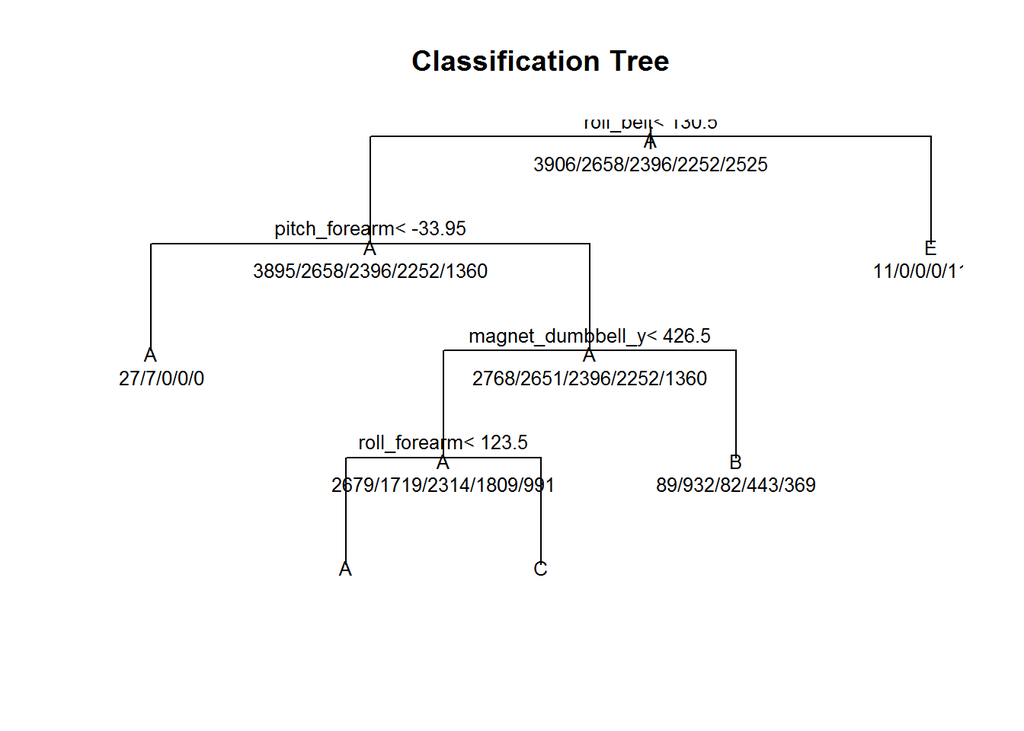

```r
plot(modFit$finalModel, uniform=TRUE, main="Classification Tree")
text(modFit$finalModel, use.n=TRUE, all=TRUE, cex=.8)
```

```r
tree_based_prediction <- predict(modFit,newdata=testing)
tree_based_prediction
```

```
##  [1] C A C A A C C A A A C C C A C A A A A C
## Levels: A B C D E
```

## Predicting with linear discriminant analysis

In this step, discriminant analysis is used for making predictions. First a model is developed using training data, it is then validated on the validating data. Finally the model is used for predictions (by deplying it on the testing data). The results of the prediction categories are presented. The discriminant analysis based model has a higher accuracy than tree based model (0.70).

```r
library(klaR)
set.seed(20000)
modlda = train(classe ~ .,data=training,method="lda")
validating_LDA <- predict(modlda,validating)
confusionMatrix(validating_LDA, validating$classe)
```

```
## Confusion Matrix and Statistics
##
##           Reference
## Prediction   A   B   C   D   E
##          A 961 114  69  43  27
##          B  27 500  69  29 125
##          C  97  98 481  73  70
##          D 102  29  90 507  84
##          E   3  35  17  26 458
##
## Overall Statistics
##
##                Accuracy : 0.7032
##                  95% CI : (0.689, 0.7171)
##     No Information Rate : 0.2879
##     P-Value [Acc > NIR] : < 2.2e-16
##
##                   Kappa : 0.6244
##  Mcnemar's Test P-Value : < 2.2e-16
##
## Statistics by Class:
##
##                      Class: A Class: B Class: C Class: D Class: E
## Sensitivity            0.8076   0.6443   0.6625   0.7478   0.5995
## Specificity            0.9141   0.9256   0.9008   0.9117   0.9760
## Pos Pred Value         0.7916   0.6667   0.5873   0.6244   0.8497
## Neg Pred Value         0.9216   0.9184   0.9261   0.9485   0.9149
## Prevalence             0.2879   0.1877   0.1756   0.1640   0.1848
## Detection Rate         0.2325   0.1209   0.1164   0.1226   0.1108
## Detection Prevalence   0.2937   0.1814   0.1981   0.1964   0.1304
## Balanced Accuracy      0.8608   0.7849   0.7817   0.8298   0.7877
```

```r
plda = predict(modlda,testing)
plda
```

```
##  [1] B A B C C C D D A A D A B A E A A B B B
## Levels: A B C D E
```

## Predicting with random forest

```r
library(randomForest)
set.seed(30000)
modFit_RF <- randomForest(classe ~ ., data=training)
validating_RF <- predict(modFit_RF, validating)
confusionMatrix(validating_RF, validating$classe)
```

```
## Confusion Matrix and Statistics
##
##           Reference
## Prediction    A    B    C    D    E
##          A 1190    0    0    0    0
##          B    0  776    0    0    0
##          C    0    0  726    0    0
##          D    0    0    0  678    0
##          E    0    0    0    0  764
##
## Overall Statistics
##
##                Accuracy : 1
##                  95% CI : (0.9991, 1)
##     No Information Rate : 0.2879
##     P-Value [Acc > NIR] : < 2.2e-16
##
##                   Kappa : 1
##  Mcnemar's Test P-Value : NA
##
## Statistics by Class:
##
##                      Class: A Class: B Class: C Class: D Class: E
## Sensitivity            1.0000   1.0000   1.0000    1.000   1.0000
## Specificity            1.0000   1.0000   1.0000    1.000   1.0000
## Pos Pred Value         1.0000   1.0000   1.0000    1.000   1.0000
## Neg Pred Value         1.0000   1.0000   1.0000    1.000   1.0000
## Prevalence             0.2879   0.1877   0.1756    0.164   0.1848
## Detection Rate         0.2879   0.1877   0.1756    0.164   0.1848
## Detection Prevalence   0.2879   0.1877   0.1756    0.164   0.1848
## Balanced Accuracy      1.0000   1.0000   1.0000    1.000   1.0000
```

```r
prediction_RF <- predict(modFit_RF, testing)
prediction_RF
```

```
##  1  2  3  4  5  6  7  8  9 10 11 12 13 14 15 16 17 18 19 20
##  B  A  B  A  A  E  D  B  A  A  B  C  B  A  E  E  A  B  B  B
## Levels: A B C D E
```